# nesa_test

Chenkai Ma

2026-04-24

## R Markdown

This is an R Markdown document.

# Github data and code repository

https://github.com/mackaay/nesa_final/tree/main

## Task1

The smallest possible value of the algebraic dimension of $X$ is 10.

## Task2

Using aluminium.csv, which contains columns strain and stress, fit a one-breakpoint Bayesian piecewise linear model to estimate the yield point of the aluminium sample.

### Load the dataset

Loading data and visualize the relation of two variables

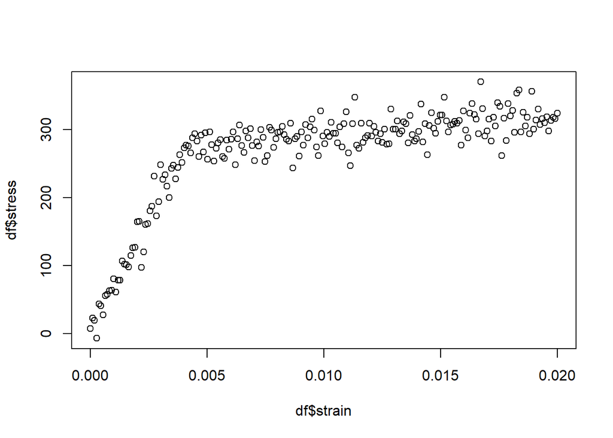

```r
df <- read.csv("./aluminium.csv")
plot(df$stress ~ df$strain)
```

```r
x <- df$strain
y <- df$stress
n <- length(y)
```

### Prior Hyperparameters

Setting the parameters , according to the instruction

```r
beta_0_val <- 30000
v_0_val <- 20000^2
beta0 <- c(beta_0_val, beta_0_val)
V0 <- diag(c(v_0_val, v_0_val))
invV0 <- solve(V0)
a0 <- 4
b0 <- 13.12
```

### Candidate breakpoints: unique internal strain values

```r
taus <- sort(unique(x))
taus <- taus[taus > min(x) & taus < max(x)]
```

### Vector to store log marginal likelihood for each tau

```r
log_marg_lik <- numeric(length(taus))
```

```r
for (i in 1:length(taus)) {
  tau <- taus[i]

  # Define the design matrix Z based on the piecewise structure:
  # mu = beta1 * min(x, tau) + beta2 * max(0, x - tau)
  z1 <- pmin(x, tau)
  z2 <- pmax(0, x - tau)
  Z <- cbind(z1, z2)

  # Update parameters for the Normal-Inverse-Gamma posterior
  Vn <- solve(invV0 + t(Z) %*% Z)
  betan <- Vn %*% (invV0 %*% beta0 + t(Z) %*% y)
  an <- a0 + n/2

  # b_n calculation for the conjugate NIG prior
  # bn = b0 + 0.5 * (y'y + beta0' V0^-1 beta0 - betan' Vn^-1 betan)
  term_y <- t(y) %*% y
  term_prior <- t(beta0) %*% invV0 %*% beta0
  term_post <- t(betan) %*% solve(Vn) %*% betan
  bn <- as.numeric(b0 + 0.5 * (term_y + term_prior - term_post))

  # Calculate the log marginal likelihood log p(y | tau)
  # Dropping constants that do not depend on tau
  log_marg_lik[i] <- -an * log(bn) + 0.5 * determinant(Vn, logarithm = TRUE)$modulus
}
```

### Calculate the posterior probabilities of tau (discrete)

```r
post_tau_unnorm <- exp(log_marg_lik - max(log_marg_lik))
post_tau <- post_tau_unnorm / sum(post_tau_unnorm)
```

### Point Estimates

Return the breakpoint values

```r
yield_point_mean <- sum(taus * post_tau)
yield_point_map <- taus[which.max(post_tau)]
```

### Display Results

```
## --- Bayesian Piecewise Linear Model Results ---
```

```
## Posterior Mean (Expected Yield Point): 0.004036012
```

```
## MAP Estimate (Mode of Posterior):     0.004018265
```

### Visualization of post yield point

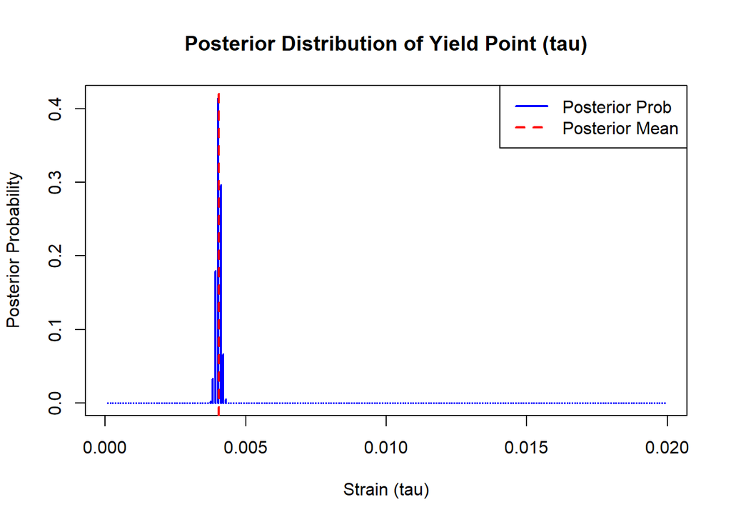

[figure not shown]

```r
plot(taus, post_tau, type = "h", col = "blue", lwd = 2,
     main = "Posterior Distribution of Yield Point (tau)",
     xlab = "Strain (tau)", ylab = "Posterior Probability")
abline(v = yield_point_mean, col = "red", lty = 2, lwd = 2)
legend("topright", legend = c("Posterior Prob", "Posterior Mean"),
       col = c("blue", "red"), lty = c(1, 2), lwd = 2)
```

### Visualization of fit plot

Storage for results

```r
log_marg_lik <- numeric(length(taus))
beta_means <- matrix(0, nrow = length(taus), ncol = 2)
```

```r
for (i in seq_along(taus)) {
  tau <- taus[i]
  # Basis functions for the continuous piecewise model
  z1 <- pmin(x, tau)
  z2 <- pmax(0, x - tau)
  Z <- cbind(z1, z2)

  # Posterior parameters for beta and sigma^2 given tau
  Vn <- solve(invV0 + t(Z) %*% Z)
  betan <- Vn %*% (invV0 %*% beta0 + t(Z) %*% y)
  an <- a0 + n/2

  # bn calculation (sum of squares term for NIG prior)
  term_ss <- as.numeric(t(y) %*% y + t(beta0) %*% invV0 %*% beta0 - t(betan) %*% solve(Vn) %*% betan)
  bn <- b0 + 0.5 * term_ss

  # Log-marginal likelihood: log p(y | tau)
  # Includes determinant and bn terms (constants independent of tau can be ignored)
  log_marg_lik[i] <- 0.5 * determinant(Vn, logarithm = TRUE)$modulus - an * log(bn)

  # Store the posterior mean of beta for this tau
  beta_means[i, ] <- betan
}
```

Compute Posterior Probabilities of tau

```r
post_probs <- exp(log_marg_lik - max(log_marg_lik))
post_probs <- post_probs / sum(post_probs)
```

Calculate the Posterior Mean Curve

```r
x_grid <- seq(min(x), max(x), length.out = 200)
y_post_mean <- numeric(length(x_grid))

for (i in seq_along(taus)) {
  tau_i <- taus[i]
  prob_i <- post_probs[i]
  b_i <- beta_means[i, ]

  # Contribution of this tau to the expected curve:
  # mu(x|tau) = beta1 * min(x, tau) + beta2 * max(0, x - tau)
  y_post_mean <- y_post_mean + prob_i * (b_i[1] * pmin(x_grid, tau_i) + b_i[2] * pmax(0, x_grid - tau_i))
}
```

plotting

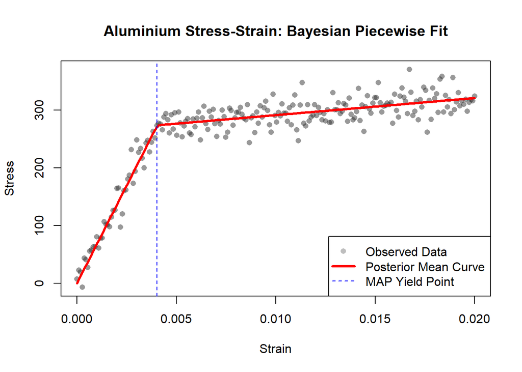

```r
plot(x, y, pch = 16, col = rgb(0.2, 0.2, 0.2, 0.5),
     main = "Aluminium Stress-Strain: Bayesian Piecewise Fit",
     xlab = "Strain", ylab = "Stress")

# Add the posterior mean curve
lines(x_grid, y_post_mean, col = "red", lwd = 3)

map_tau <- taus[which.max(post_probs)]
abline(v = map_tau, col = "blue", lty = 2)

legend("bottomright", legend = c("Observed Data", "Posterior Mean Curve", "MAP Yield Point"),
       col = c("gray", "red", "blue"), pch = c(16, NA, NA), lty = c(NA, 1, 2), lwd = c(NA, 3, 1))
```

Since the priors for $\beta$ and $\sigma^2$ are conjugate (Normal-Inverse-Gamma) when $\tau$ is fixed, I can bypass MCMC sampling entirely and calculate the marginal likelihood for each candidate breakpoint directly. My Implementation Approach I treated the breakpoint $\tau$ as a discrete parameter. By iterating through each candidate strain value, I updated the model’s beliefs using the following logic:Feature Engineering: I transformed the continuous strain into two “basis” variables—one representing the elastic phase and one representing the plastic phase—ensuring they meet at $\tau$. Exact Integration: For every $\tau$, I computed the posterior parameters and the marginal likelihood (the probability of the data given only $\tau$). Bayesian Model Averaging: The “fitted curve” is not just the best fit, but a weighted average of all possible models, weighted by their posterior probabilities.

If the number of candidate breakpoints increases substantially, evaluating every single one is no longer feasible. Stochastic Search: Use MCMC (like Hamiltonian Monte Carlo in Stan) to treat $\tau$ as a continuous variable. The algorithm “walks” toward the most likely yield points rather than checking every possibility. Coarse-to-Fine Grid: Start with a sparse set of breakpoints to find the general “yield region,” then initialize a dense search only in that high-probability area.

## Task4

Include your technical writing sample in the submission, together with a short note explaining its context, your role in writing it, and the intended audience.

This analysis provides a robust, probabilistic method for identifying the yield point—the critical transition where a material stops behaving elastically and begins to deform permanently—of an aluminium sample. By applying a Bayesian Piecewise Linear Model, the analysis moves beyond simple “best-guess” line fitting to provide a full picture of uncertainty.

Intended Audience: The intended audience is Junior Data Scientists and stakeholders who understand the basics of stress-strain curves.